# RNAsep Assemblies & Annotation Report

Thomas Sol Dourdin

2025-04-09

# **RNAsep2 Transcriptome Assembly**

The RNAsep2 transcriptome assembly was carried out using 4 samples from each condition (*c.a.* 16 samples) after raw data trimming and quality filtering.

The assembly was performed with the *Trinity* suite, then thinned with *cd-hit* to remove redundancy and several metrics were calculated in order to assess its quality. The thinned assembly is 229,360,960 bp long (~230.10<sup>6</sup> bp). Given the assembly length, the mean length of trimmed reads (146 bp) and the mean number of paired-end reads per sample (19.10^6), **the average sequencing depth per sample is about 24X**.

The results of the assembly quality assessment are summarized in the following table:

| Metric | Raw | Thin | Type |
| --- | --- | --- | --- |
| Number of Trinity “genes” | 331430 | 325104 | Baseline |
| Number of transcripts | 483699 | 397569 | Baseline |
| GC content (%) | 36.94 | 36.65 | Baseline |
| Smallest transcript | 179 | 182 | Baseline |
| Largest transcript | 33040 | 33040 | Baseline |
| Mean transcript length | 621 | 577 | Baseline |
| Bases with N (ambiguity) | 0 | 0 | Baseline |
| Proportion of N bases | 0 | 0 | Baseline |
| N50 (longest isoform per gene) | 594 | 600 | Baseline |
| E90N50 | 2005 | 1990 | Baseline |
| Predicted number of transcripts with ORF | 43409 | 31200 | Baseline |
| Mean ORF (%) | 49.5 | 48.5 | Baseline |
| **Completeness - BUSCO** |  |  |  |
| Mollusca_odb Complete and Single-copy (%) | 38.9 | 51.8 | Completeness |
| Mollusca_odb Complete and duplicated (%) | 48.6 | 35.4 | Completeness |
| Metazoa_odb Complete and Single-copy (%) | 59.5 | 71.5 | Completeness |
| Metazoa_odb Complete and duplicated (%) | 38.8 | 26.7 | Completeness |
| **FullLength - Blastx** |  |  |  |
| Number of proteins matching Trinity transcript from 80% to 90% of their protein length | 1467 | 1451 | FullLength |
| Number of proteins reprented by nearly full-length (>80%) transcripts | 5388 | 5271 | FullLength |
| **ReadContent - STAR** |  |  |  |
| Aligned reads (%) | 94.0 | 95.8 | ReadContent |

Based on this assessment, we can assume that **the assembly is of good quality** in terms of transcripts length and representation of conserved transcripts.

## **Assembly structural and functional annotation**

### **Structural annotation**

The identification of potentially protein-coding regions in transcripts was performed with *TransDecoder* on the thinned assembly. Overall, **49402 ORFs** were identified and then submited to functional annotation.

### **Functional annotation**

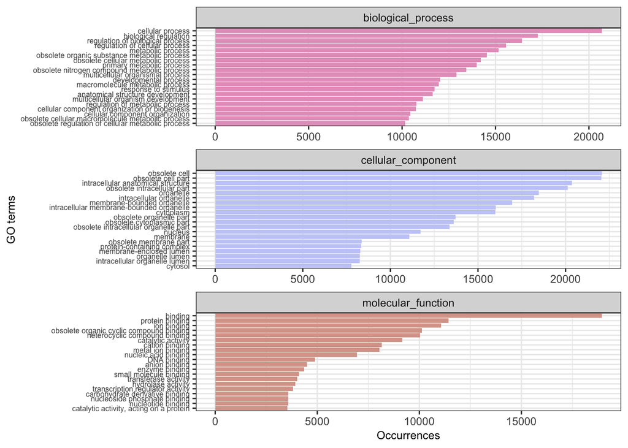

- **Reactome** was also used to predict the pathways in which the assembled transcripts were involved. The following figure shows the number of transcripts related to the main Reactome pathways:

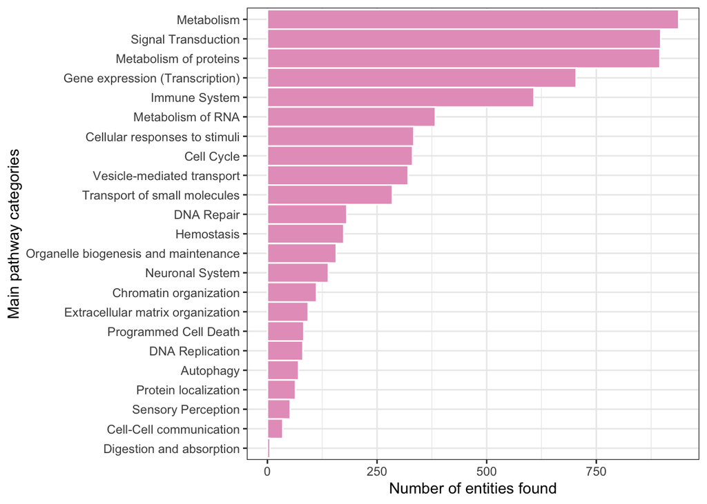

Finally, the efficiency of each annotation type is summarised in the figure below:

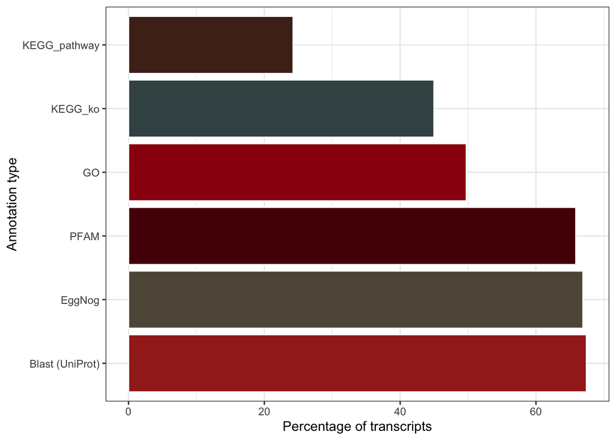

# **RNAsep1 Transcriptome Assembly**

The results of the assembly quality assessment are summarized in the following table:

| Metric | Assembly_Raw | Assembly_Thin |
| --- | --- | --- |
| Number of Trinity “genes” | 207672 | 204818 |
| Number of transcripts | 282660 | 244772 |
| GC content (%) | 36.4 | 36.13 |
| Smallest transcript | 174 | 180 |
| Largest transcript | 36551 | 36551 |
| Mean transcript length | 741.29 | 687.16 |
| Bases with N (ambiguity) | 0 | 0 |
| Proportion of N bases | 0 | 0 |
| N50 (longest isoform per gene) | 758 | 764 |
| E90N50 | 1932 | 1923 |
| Predicted number of transcripts with ORF | 35681 | 26968 |
| Mean ORF (%) | 49.43 | 47.97 |
| **Completeness - BUSCO** |  |  |
| Mollusca_odb Complete and Single-copy (%) | 43.9 | 55.3 |
| Mollusca_odb Complete and duplicated (%) | 43.0 | 31.4 |
| Metazoa_odb Complete and Single-copy (%) | 61.7 | 73.2 |
| Metazoa_odb Complete and duplicated (%) | 36.2 | 24.7 |
| **FullLength - Blastx** |  |  |
| Number of proteins matching Trinity transcript from 80% to 90% of their protein length | 1295 | 1374 |
| Number of proteins reprented by nearly full-length (>80%) transcripts | 4901 | 5174 |
| **ReadContent - STAR** |  |  |
| Aligned reads (%) | 94.8 | 94.7 |

Based on this assessment, we can assume that **the assembly is of good quality** in terms of transcripts length and representation of conserved transcripts.

## **Assembly structural and functional annotation**

### **Functional annotation**

Several tools were used to annotate the assembly :

- **BLAST (x & p)** annotated 28407 transcripts against the SwissProt UniProt database;
- **EggNOG-mapper** identified 28313 orthologous hits and annotated 21692 transcripts with GO terms, 19471 transcripts with KEGG_ko, 10775 transcripts associated to KEGG_pathways and 27868 transcripts matching PFAM entries. The occurrence of the top 20 GO terms by spacename are represented in the following figure:

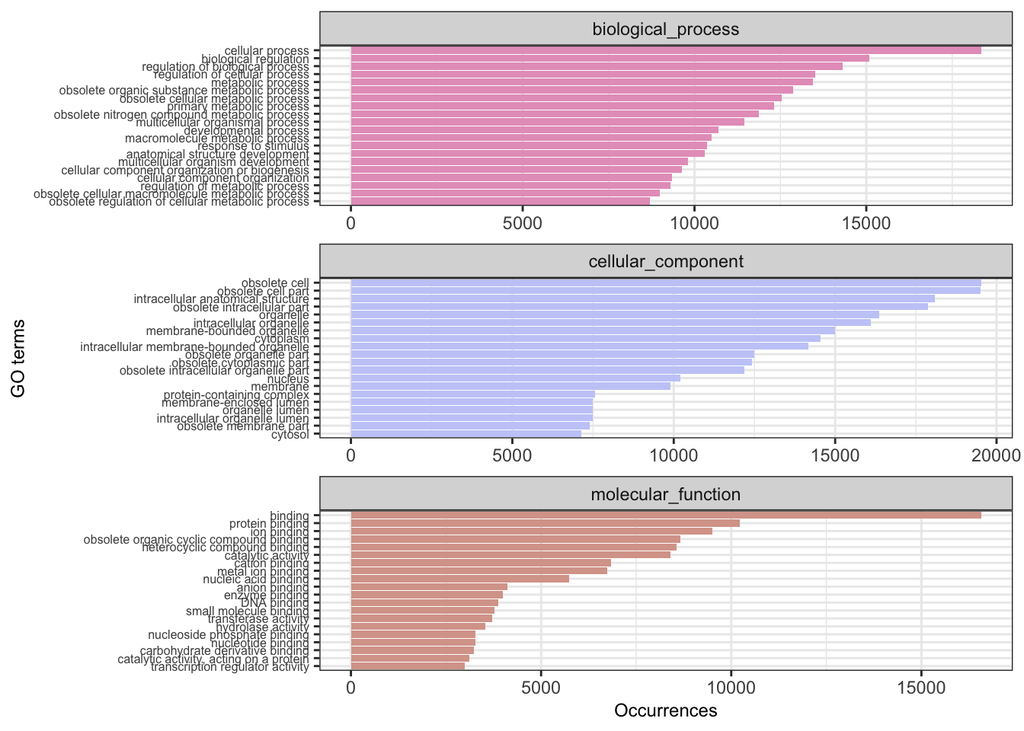

- **Reactome** was also used to predict the pathways in which the assembled transcripts were involved. The following figure shows the number of transcripts related to the main Reactome pathways:

[figure not shown]

Finally, the efficiency of each annotation type is summarised in the figure below:

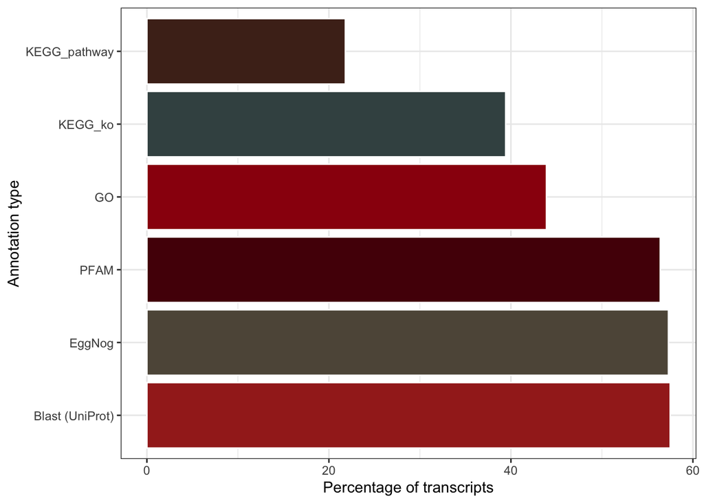

# **Current state of the annotation R workflow**

[interactive chart not shown]